# W3cubDocs

/Matplotlib 3.5

# matplotlib.axes.Axes.set_title

**Axes.set_title(*label*, *fontdict=None*, *loc=None*, *pad=None*, *, *y=None*, **kwargs)[[source]](https://github.com/matplotlib/matplotlib/blob/v3.5.1/lib/matplotlib/axes/_axes.py#L93-L170)**

Set a title for the Axes.

Set one of the three available Axes titles. The available titles are positioned above the Axes in the center, flush with the left edge, and flush with the right edge.

**Parameters**

**label**str**

Text to use for the title

**fontdict**dict**

A dictionary controlling the appearance of the title text, the default *fontdict* is:

```
{'fontsize': rcParams['axes.titlesize'],
 'fontweight': rcParams['axes.titleweight'],
 'color': rcParams['axes.titlecolor'],
 'verticalalignment': 'baseline',
 'horizontalalignment': loc}
```

**loc**{'center', 'left', 'right'}, default: `rcParams["axes.titlelocation"]` (default: `'center'`)**

Which title to set.

**y**float, default: `rcParams["axes.titley"]` (default: `None`)**

Vertical Axes loation for the title (1.0 is the top). If None (the default), y is determined automatically to avoid decorators on the Axes.

**pad**float, default: `rcParams["axes.titlepad"]` (default: `6.0`)**

The offset of the title from the top of the Axes, in points.

**Returns**

**`Text`**

The matplotlib text instance representing the title

**Other Parameters**

**kwargs`Text` properties**

Other keyword arguments are text properties, see `Text` for a list of valid text properties.

## Examples using `matplotlib.axes.Axes.set_title`

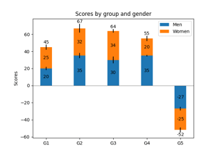

[Bar Label Demo](https://matplotlib.org/3.5.1/gallery/lines_bars_and_markers/bar_label_demo.html#sphx-glr-gallery-lines-bars-and-markers-bar-label-demo-py)

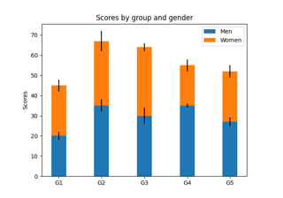

[Stacked bar chart](https://matplotlib.org/3.5.1/gallery/lines_bars_and_markers/bar_stacked.html#sphx-glr-gallery-lines-bars-and-markers-bar-stacked-py)

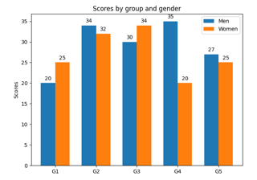

[Grouped bar chart with labels](https://matplotlib.org/3.5.1/gallery/lines_bars_and_markers/barchart.html#sphx-glr-gallery-lines-bars-and-markers-barchart-py)

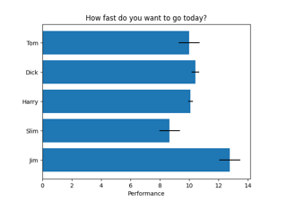

[Horizontal bar chart](https://matplotlib.org/3.5.1/gallery/lines_bars_and_markers/barh.html#sphx-glr-gallery-lines-bars-and-markers-barh-py)

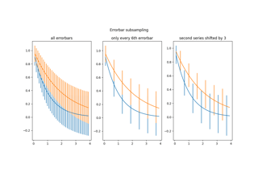

[Errorbar subsampling](https://matplotlib.org/3.5.1/gallery/lines_bars_and_markers/errorbar_subsample.html#sphx-glr-gallery-lines-bars-and-markers-errorbar-subsample-py)

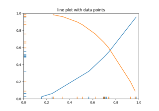

[EventCollection Demo](https://matplotlib.org/3.5.1/gallery/lines_bars_and_markers/eventcollection_demo.html#sphx-glr-gallery-lines-bars-and-markers-eventcollection-demo-py)

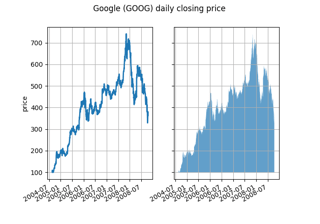

[Fill Between and Alpha](https://matplotlib.org/3.5.1/gallery/lines_bars_and_markers/fill_between_alpha.html#sphx-glr-gallery-lines-bars-and-markers-fill-between-alpha-py)

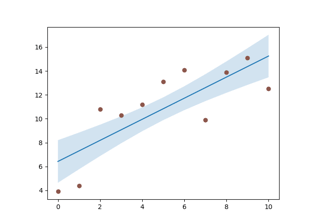

[Filling the area between lines](https://matplotlib.org/3.5.1/gallery/lines_bars_and_markers/fill_between_demo.html#sphx-glr-gallery-lines-bars-and-markers-fill-between-demo-py)

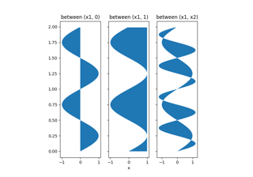

[Fill Betweenx Demo](https://matplotlib.org/3.5.1/gallery/lines_bars_and_markers/fill_betweenx_demo.html#sphx-glr-gallery-lines-bars-and-markers-fill-betweenx-demo-py)

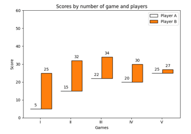

[Hat graph](https://matplotlib.org/3.5.1/gallery/lines_bars_and_markers/hat_graph.html#sphx-glr-gallery-lines-bars-and-markers-hat-graph-py)

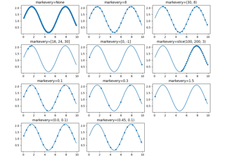

[Markevery Demo](https://matplotlib.org/3.5.1/gallery/lines_bars_and_markers/markevery_demo.html#sphx-glr-gallery-lines-bars-and-markers-markevery-demo-py)

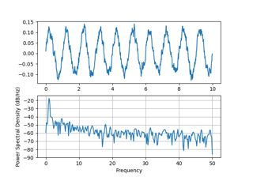

[Psd Demo](https://matplotlib.org/3.5.1/gallery/lines_bars_and_markers/psd_demo.html#sphx-glr-gallery-lines-bars-and-markers-psd-demo-py)

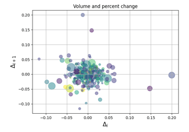

[Scatter Demo2](https://matplotlib.org/3.5.1/gallery/lines_bars_and_markers/scatter_demo2.html#sphx-glr-gallery-lines-bars-and-markers-scatter-demo2-py)

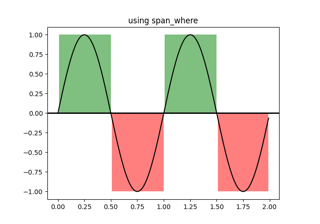

[Using span_where](https://matplotlib.org/3.5.1/gallery/lines_bars_and_markers/span_regions.html#sphx-glr-gallery-lines-bars-and-markers-span-regions-py)

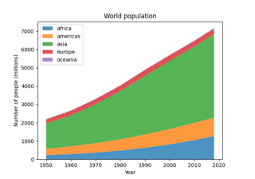

[Stackplots and streamgraphs](https://matplotlib.org/3.5.1/gallery/lines_bars_and_markers/stackplot_demo.html#sphx-glr-gallery-lines-bars-and-markers-stackplot-demo-py)

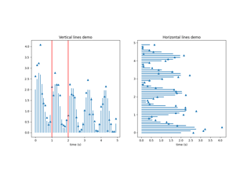

[hlines and vlines](https://matplotlib.org/3.5.1/gallery/lines_bars_and_markers/vline_hline_demo.html#sphx-glr-gallery-lines-bars-and-markers-vline-hline-demo-py)

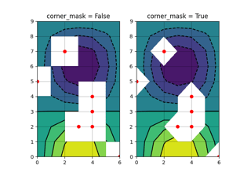

[Contour Corner Mask](https://matplotlib.org/3.5.1/gallery/images_contours_and_fields/contour_corner_mask.html#sphx-glr-gallery-images-contours-and-fields-contour-corner-mask-py)

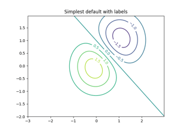

[Contour Demo](https://matplotlib.org/3.5.1/gallery/images_contours_and_fields/contour_demo.html#sphx-glr-gallery-images-contours-and-fields-contour-demo-py)

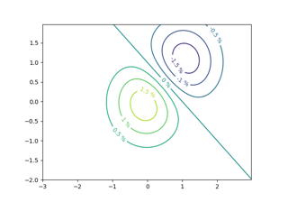

[Contour Label Demo](https://matplotlib.org/3.5.1/gallery/images_contours_and_fields/contour_label_demo.html#sphx-glr-gallery-images-contours-and-fields-contour-label-demo-py)

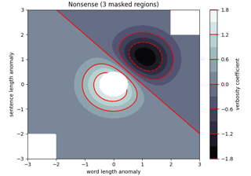

[Contourf Demo](https://matplotlib.org/3.5.1/gallery/images_contours_and_fields/contourf_demo.html#sphx-glr-gallery-images-contours-and-fields-contourf-demo-py)

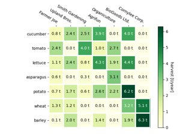

[Creating annotated heatmaps](https://matplotlib.org/3.5.1/gallery/images_contours_and_fields/image_annotated_heatmap.html#sphx-glr-gallery-images-contours-and-fields-image-annotated-heatmap-py)

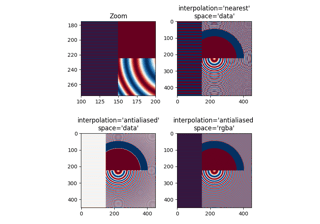

[Image antialiasing](https://matplotlib.org/3.5.1/gallery/images_contours_and_fields/image_antialiasing.html#sphx-glr-gallery-images-contours-and-fields-image-antialiasing-py)

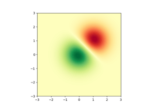

[Image Demo](https://matplotlib.org/3.5.1/gallery/images_contours_and_fields/image_demo.html#sphx-glr-gallery-images-contours-and-fields-image-demo-py)

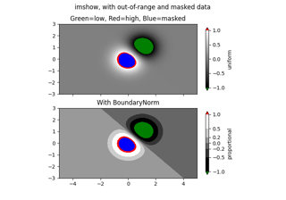

[Image Masked](https://matplotlib.org/3.5.1/gallery/images_contours_and_fields/image_masked.html#sphx-glr-gallery-images-contours-and-fields-image-masked-py)

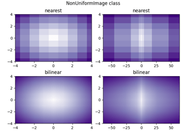

[Image Nonuniform](https://matplotlib.org/3.5.1/gallery/images_contours_and_fields/image_nonuniform.html#sphx-glr-gallery-images-contours-and-fields-image-nonuniform-py)

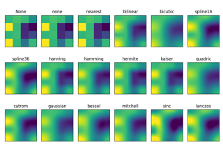

[Interpolations for imshow](https://matplotlib.org/3.5.1/gallery/images_contours_and_fields/interpolation_methods.html#sphx-glr-gallery-images-contours-and-fields-interpolation-methods-py)

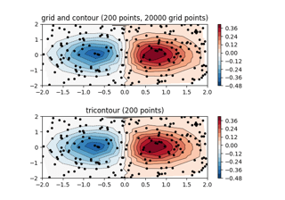

[Contour plot of irregularly spaced data](https://matplotlib.org/3.5.1/gallery/images_contours_and_fields/irregulardatagrid.html#sphx-glr-gallery-images-contours-and-fields-irregulardatagrid-py)

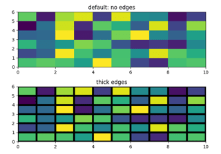

[Pcolor Demo](https://matplotlib.org/3.5.1/gallery/images_contours_and_fields/pcolor_demo.html#sphx-glr-gallery-images-contours-and-fields-pcolor-demo-py)

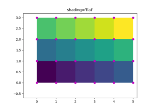

[pcolormesh grids and shading](https://matplotlib.org/3.5.1/gallery/images_contours_and_fields/pcolormesh_grids.html#sphx-glr-gallery-images-contours-and-fields-pcolormesh-grids-py)

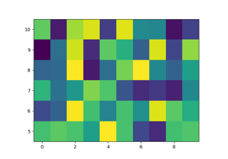

[pcolormesh](https://matplotlib.org/3.5.1/gallery/images_contours_and_fields/pcolormesh_levels.html#sphx-glr-gallery-images-contours-and-fields-pcolormesh-levels-py)

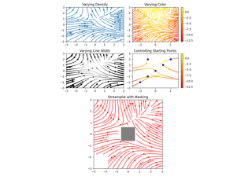

[Streamplot](https://matplotlib.org/3.5.1/gallery/images_contours_and_fields/plot_streamplot.html#sphx-glr-gallery-images-contours-and-fields-plot-streamplot-py)

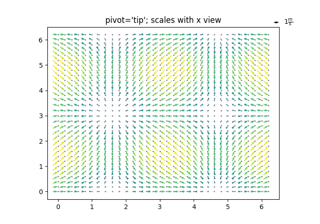

[Advanced quiver and quiverkey functions](https://matplotlib.org/3.5.1/gallery/images_contours_and_fields/quiver_demo.html#sphx-glr-gallery-images-contours-and-fields-quiver-demo-py)

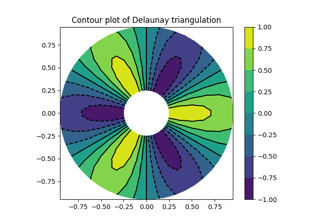

[Tricontour Demo](https://matplotlib.org/3.5.1/gallery/images_contours_and_fields/tricontour_demo.html#sphx-glr-gallery-images-contours-and-fields-tricontour-demo-py)

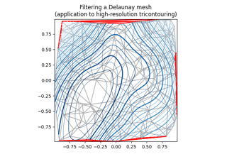

[Tricontour Smooth Delaunay](https://matplotlib.org/3.5.1/gallery/images_contours_and_fields/tricontour_smooth_delaunay.html#sphx-glr-gallery-images-contours-and-fields-tricontour-smooth-delaunay-py)

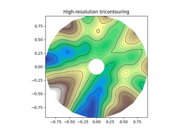

[Tricontour Smooth User](https://matplotlib.org/3.5.1/gallery/images_contours_and_fields/tricontour_smooth_user.html#sphx-glr-gallery-images-contours-and-fields-tricontour-smooth-user-py)

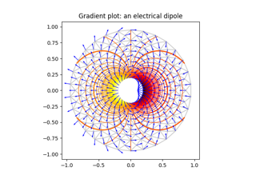

[Trigradient Demo](https://matplotlib.org/3.5.1/gallery/images_contours_and_fields/trigradient_demo.html#sphx-glr-gallery-images-contours-and-fields-trigradient-demo-py)

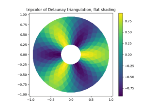

[Tripcolor Demo](https://matplotlib.org/3.5.1/gallery/images_contours_and_fields/tripcolor_demo.html#sphx-glr-gallery-images-contours-and-fields-tripcolor-demo-py)

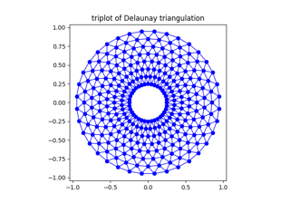

[Triplot Demo](https://matplotlib.org/3.5.1/gallery/images_contours_and_fields/triplot_demo.html#sphx-glr-gallery-images-contours-and-fields-triplot-demo-py)

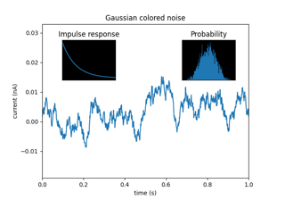

[Axes Demo](https://matplotlib.org/3.5.1/gallery/subplots_axes_and_figures/axes_demo.html#sphx-glr-gallery-subplots-axes-and-figures-axes-demo-py)

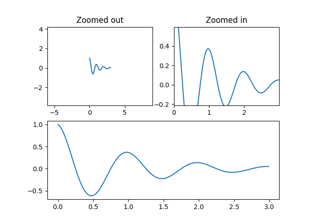

[Controlling view limits using margins and sticky_edges](https://matplotlib.org/3.5.1/gallery/subplots_axes_and_figures/axes_margins.html#sphx-glr-gallery-subplots-axes-and-figures-axes-margins-py)

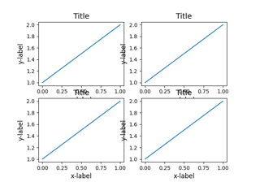

[Resizing axes with constrained layout](https://matplotlib.org/3.5.1/gallery/subplots_axes_and_figures/demo_constrained_layout.html#sphx-glr-gallery-subplots-axes-and-figures-demo-constrained-layout-py)

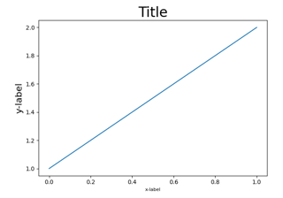

[Resizing axes with tight layout](https://matplotlib.org/3.5.1/gallery/subplots_axes_and_figures/demo_tight_layout.html#sphx-glr-gallery-subplots-axes-and-figures-demo-tight-layout-py)

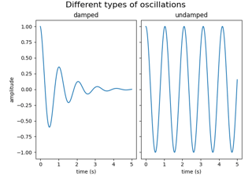

[Figure labels: suptitle, supxlabel, supylabel](https://matplotlib.org/3.5.1/gallery/subplots_axes_and_figures/figure_title.html#sphx-glr-gallery-subplots-axes-and-figures-figure-title-py)

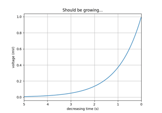

[Invert Axes](https://matplotlib.org/3.5.1/gallery/subplots_axes_and_figures/invert_axes.html#sphx-glr-gallery-subplots-axes-and-figures-invert-axes-py)

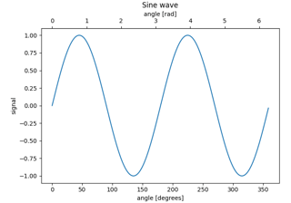

[Secondary Axis](https://matplotlib.org/3.5.1/gallery/subplots_axes_and_figures/secondary_axis.html#sphx-glr-gallery-subplots-axes-and-figures-secondary-axis-py)

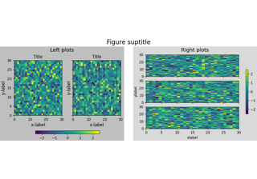

[Figure subfigures](https://matplotlib.org/3.5.1/gallery/subplots_axes_and_figures/subfigures.html#sphx-glr-gallery-subplots-axes-and-figures-subfigures-py)

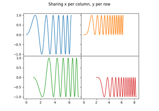

[Creating multiple subplots using plt.subplots](https://matplotlib.org/3.5.1/gallery/subplots_axes_and_figures/subplots_demo.html#sphx-glr-gallery-subplots-axes-and-figures-subplots-demo-py)

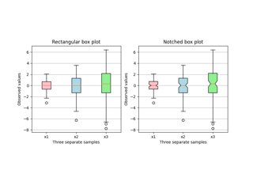

[Box plots with custom fill colors](https://matplotlib.org/3.5.1/gallery/statistics/boxplot_color.html#sphx-glr-gallery-statistics-boxplot-color-py)

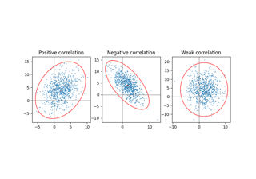

[Plot a confidence ellipse of a two-dimensional dataset](https://matplotlib.org/3.5.1/gallery/statistics/confidence_ellipse.html#sphx-glr-gallery-statistics-confidence-ellipse-py)

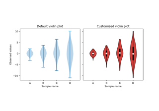

[Violin plot customization](https://matplotlib.org/3.5.1/gallery/statistics/customized_violin.html#sphx-glr-gallery-statistics-customized-violin-py)

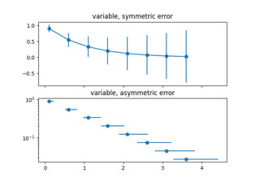

[Different ways of specifying error bars](https://matplotlib.org/3.5.1/gallery/statistics/errorbar_features.html#sphx-glr-gallery-statistics-errorbar-features-py)

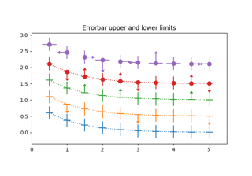

[Including upper and lower limits in error bars](https://matplotlib.org/3.5.1/gallery/statistics/errorbar_limits.html#sphx-glr-gallery-statistics-errorbar-limits-py)

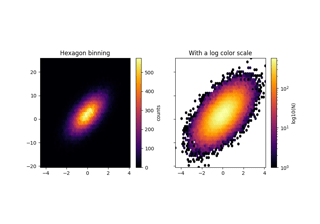

[Hexagonal binned plot](https://matplotlib.org/3.5.1/gallery/statistics/hexbin_demo.html#sphx-glr-gallery-statistics-hexbin-demo-py)

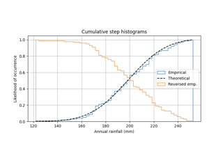

[Using histograms to plot a cumulative distribution](https://matplotlib.org/3.5.1/gallery/statistics/histogram_cumulative.html#sphx-glr-gallery-statistics-histogram-cumulative-py)